# Линейная регрессия и стохастический градиентный спуск

решаем задачу: $$\Large \frac{1}{\ell}\sum_{i=1}^\ell{{((w_0 + w_1x_{i1} + w_2x_{i2} + w_3x_{i3}) + ... - y_i)}^2} \rightarrow \min_{w_0, w_1, w_2, w_3},$$ где $x_{i1}, x_{i2}, x_{i3}$ - значения признаков $i$-го объекта, $y_i$ - значение целевого признака $i$-го объекта, $\ell$ - число объектов в обучающей выборке.

Загружаем данные из файла *advertising.csv* в объект pandas DataFrame. [Источник данных](http://www-bcf.usc.edu/~gareth/ISL/data.html).**

```python
import pandas as pd
adver_data = pd.read_csv('advertising.csv')
```

первые 5 записей и статистика признаков

```python
import numpy as np
%matplotlib inline
```

```python
adver_data.head()
```

|  | TV | Radio | Newspaper | Sales |
| --- | --- | --- | --- | --- |
| 1 | 230.1 | 37.8 | 69.2 | 22.1 |
| 2 | 44.5 | 39.3 | 45.1 | 10.4 |
| 3 | 17.2 | 45.9 | 69.3 | 9.3 |
| 4 | 151.5 | 41.3 | 58.5 | 18.5 |
| 5 | 180.8 | 10.8 | 58.4 | 12.9 |

```python
adver_data
```

|  | TV | Radio | Newspaper | Sales |
| --- | --- | --- | --- | --- |
| 1 | 230.1 | 37.8 | 69.2 | 22.1 |
| 2 | 44.5 | 39.3 | 45.1 | 10.4 |
| 3 | 17.2 | 45.9 | 69.3 | 9.3 |
| 4 | 151.5 | 41.3 | 58.5 | 18.5 |
| 5 | 180.8 | 10.8 | 58.4 | 12.9 |
| 6 | 8.7 | 48.9 | 75.0 | 7.2 |
| 7 | 57.5 | 32.8 | 23.5 | 11.8 |
| 8 | 120.2 | 19.6 | 11.6 | 13.2 |
| 9 | 8.6 | 2.1 | 1.0 | 4.8 |
| 10 | 199.8 | 2.6 | 21.2 | 10.6 |
| 11 | 66.1 | 5.8 | 24.2 | 8.6 |
| 12 | 214.7 | 24.0 | 4.0 | 17.4 |
| 13 | 23.8 | 35.1 | 65.9 | 9.2 |
| 14 | 97.5 | 7.6 | 7.2 | 9.7 |
| 15 | 204.1 | 32.9 | 46.0 | 19.0 |
| 16 | 195.4 | 47.7 | 52.9 | 22.4 |
| 17 | 67.8 | 36.6 | 114.0 | 12.5 |
| 18 | 281.4 | 39.6 | 55.8 | 24.4 |
| 19 | 69.2 | 20.5 | 18.3 | 11.3 |
| 20 | 147.3 | 23.9 | 19.1 | 14.6 |
| 21 | 218.4 | 27.7 | 53.4 | 18.0 |
| 22 | 237.4 | 5.1 | 23.5 | 12.5 |
| 23 | 13.2 | 15.9 | 49.6 | 5.6 |
| 24 | 228.3 | 16.9 | 26.2 | 15.5 |
| 25 | 62.3 | 12.6 | 18.3 | 9.7 |
| 26 | 262.9 | 3.5 | 19.5 | 12.0 |
| 27 | 142.9 | 29.3 | 12.6 | 15.0 |
| 28 | 240.1 | 16.7 | 22.9 | 15.9 |
| 29 | 248.8 | 27.1 | 22.9 | 18.9 |
| 30 | 70.6 | 16.0 | 40.8 | 10.5 |
| ... | ... | ... | ... | ... |
| 171 | 50.0 | 11.6 | 18.4 | 8.4 |
| 172 | 164.5 | 20.9 | 47.4 | 14.5 |
| 173 | 19.6 | 20.1 | 17.0 | 7.6 |
| 174 | 168.4 | 7.1 | 12.8 | 11.7 |
| 175 | 222.4 | 3.4 | 13.1 | 11.5 |
| 176 | 276.9 | 48.9 | 41.8 | 27.0 |
| 177 | 248.4 | 30.2 | 20.3 | 20.2 |
| 178 | 170.2 | 7.8 | 35.2 | 11.7 |
| 179 | 276.7 | 2.3 | 23.7 | 11.8 |
| 180 | 165.6 | 10.0 | 17.6 | 12.6 |
| 181 | 156.6 | 2.6 | 8.3 | 10.5 |
| 182 | 218.5 | 5.4 | 27.4 | 12.2 |
| 183 | 56.2 | 5.7 | 29.7 | 8.7 |
| 184 | 287.6 | 43.0 | 71.8 | 26.2 |
| 185 | 253.8 | 21.3 | 30.0 | 17.6 |
| 186 | 205.0 | 45.1 | 19.6 | 22.6 |
| 187 | 139.5 | 2.1 | 26.6 | 10.3 |
| 188 | 191.1 | 28.7 | 18.2 | 17.3 |
| 189 | 286.0 | 13.9 | 3.7 | 15.9 |
| 190 | 18.7 | 12.1 | 23.4 | 6.7 |
| 191 | 39.5 | 41.1 | 5.8 | 10.8 |
| 192 | 75.5 | 10.8 | 6.0 | 9.9 |
| 193 | 17.2 | 4.1 | 31.6 | 5.9 |
| 194 | 166.8 | 42.0 | 3.6 | 19.6 |
| 195 | 149.7 | 35.6 | 6.0 | 17.3 |
| 196 | 38.2 | 3.7 | 13.8 | 7.6 |
| 197 | 94.2 | 4.9 | 8.1 | 9.7 |
| 198 | 177.0 | 9.3 | 6.4 | 12.8 |
| 199 | 283.6 | 42.0 | 66.2 | 25.5 |
| 200 | 232.1 | 8.6 | 8.7 | 13.4 |

200 rows × 4 columns

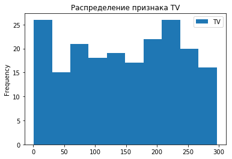

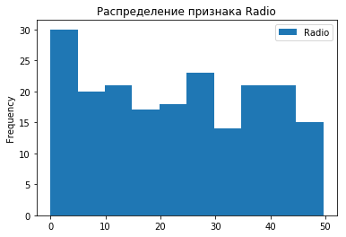

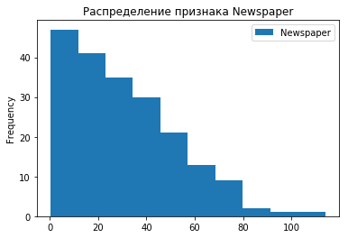

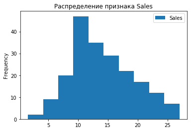

```python
for mark in ('TV', 'Radio', 'Newspaper', 'Sales'):
    adver_data.plot(y=mark, kind='hist', title=u'Распределение признака '+mark)
```

массивы NumPy *X* из столбцов TV, Radio и Newspaper и *y* - из столбца Sales

```python
type(adver_data['TV'].values)
```

```
numpy.ndarray
```

```python
X = np.array([adver_data[sign].values for sign in ('TV', 'Radio', 'Newspaper') ]).T # Ваш код здесь
y = np.array([adver_data['Sales'].values]).T # Ваш код здесь
print X.ndim, X.size
print X, y
```

```
2 600
[[ 230.1   37.8   69.2]
 [  44.5   39.3   45.1]
 [  17.2   45.9   69.3]
 [ 151.5   41.3   58.5]
 [ 180.8   10.8   58.4]
 [   8.7   48.9   75. ]
 [  57.5   32.8   23.5]
 [ 120.2   19.6   11.6]
 [   8.6    2.1    1. ]
 [ 199.8    2.6   21.2]
 [  66.1    5.8   24.2]
 [ 214.7   24.     4. ]
 [  23.8   35.1   65.9]
 [  97.5    7.6    7.2]
 [ 204.1   32.9   46. ]
 [ 195.4   47.7   52.9]
 [  67.8   36.6  114. ]
 [ 281.4   39.6   55.8]
 [  69.2   20.5   18.3]
 [ 147.3   23.9   19.1]
 [ 218.4   27.7   53.4]
 [ 237.4    5.1   23.5]
 [  13.2   15.9   49.6]
 [ 228.3   16.9   26.2]
 [  62.3   12.6   18.3]
 [ 262.9    3.5   19.5]
 [ 142.9   29.3   12.6]
 [ 240.1   16.7   22.9]
 [ 248.8   27.1   22.9]
 [  70.6   16.    40.8]
 [ 292.9   28.3   43.2]
 [ 112.9   17.4   38.6]
 [  97.2    1.5   30. ]
 [ 265.6   20.     0.3]
 [  95.7    1.4    7.4]
 [ 290.7    4.1    8.5]
 [ 266.9   43.8    5. ]
 [  74.7   49.4   45.7]
 [  43.1   26.7   35.1]
```

[output cut: 345 more lines]

```
 [ 22.6]
 [ 10.3]
 [ 17.3]
 [ 15.9]
 [  6.7]
 [ 10.8]
 [  9.9]
 [  5.9]
 [ 19.6]
 [ 17.3]
 [  7.6]
 [  9.7]
 [ 12.8]
 [ 25.5]
 [ 13.4]]
```

**масштабируем столбцы матрицы *X***

```python
# пробуем
print X.mean(axis=0), X.std(axis=0)
```

```
[ 147.0425   23.264    30.554 ] [ 85.63933176  14.80964564  21.72410606]
```

```python
means, stds = X.mean(axis=0), X.std(axis=0)
print means, stds
```

[output not shown]

```python
X = (X - means)/stds
```

```python
# проверяем
#X[:,0].size
print X.shape[0], X.shape
np.ones(X.shape[0])
```

```
200 (200L, 3L)
```

```
array([ 1.,  1.,  1.,  1.,  1.,  1.,  1.,  1.,  1.,  1.,  1.,  1.,  1.,
        1.,  1.,  1.,  1.,  1.,  1.,  1.,  1.,  1.,  1.,  1.,  1.,  1.,
        1.,  1.,  1.,  1.,  1.,  1.,  1.,  1.,  1.,  1.,  1.,  1.,  1.,
        1.,  1.,  1.,  1.,  1.,  1.,  1.,  1.,  1.,  1.,  1.,  1.,  1.,
        1.,  1.,  1.,  1.,  1.,  1.,  1.,  1.,  1.,  1.,  1.,  1.,  1.,
        1.,  1.,  1.,  1.,  1.,  1.,  1.,  1.,  1.,  1.,  1.,  1.,  1.,
        1.,  1.,  1.,  1.,  1.,  1.,  1.,  1.,  1.,  1.,  1.,  1.,  1.,
        1.,  1.,  1.,  1.,  1.,  1.,  1.,  1.,  1.,  1.,  1.,  1.,  1.,
        1.,  1.,  1.,  1.,  1.,  1.,  1.,  1.,  1.,  1.,  1.,  1.,  1.,
        1.,  1.,  1.,  1.,  1.,  1.,  1.,  1.,  1.,  1.,  1.,  1.,  1.,
        1.,  1.,  1.,  1.,  1.,  1.,  1.,  1.,  1.,  1.,  1.,  1.,  1.,
        1.,  1.,  1.,  1.,  1.,  1.,  1.,  1.,  1.,  1.,  1.,  1.,  1.,
        1.,  1.,  1.,  1.,  1.,  1.,  1.,  1.,  1.,  1.,  1.,  1.,  1.,
        1.,  1.,  1.,  1.,  1.,  1.,  1.,  1.,  1.,  1.,  1.,  1.,  1.,
        1.,  1.,  1.,  1.,  1.,  1.,  1.,  1.,  1.,  1.,  1.,  1.,  1.,
        1.,  1.,  1.,  1.,  1.])
```

**Добавляем к матрице *X* столбец из единиц, чтобы не обрабатывать отдельно коэффициент $w_0$ линейной регрессии.**

```python
import numpy as np
d = X.shape[0]
ones_for_X = np.ones(d).reshape(d,1)
ones_and_X = np.hstack((ones_for_X, X))
```

```python
# проверки
print ones_and_X
print type(ones_and_X)
print ones_and_X.shape
```

```
[[  1.00000000e+00   9.69852266e-01   9.81522472e-01   1.77894547e+00]
 [  1.00000000e+00  -1.19737623e+00   1.08280781e+00   6.69578760e-01]
 [  1.00000000e+00  -1.51615499e+00   1.52846331e+00   1.78354865e+00]
 [  1.00000000e+00   5.20496822e-02   1.21785493e+00   1.28640506e+00]
 [  1.00000000e+00   3.94182198e-01  -8.41613655e-01   1.28180188e+00]
 [  1.00000000e+00  -1.61540845e+00   1.73103399e+00   2.04592999e+00]
 [  1.00000000e+00  -1.04557682e+00   6.43904671e-01  -3.24708413e-01]
 [  1.00000000e+00  -3.13436589e-01  -2.47406325e-01  -8.72486994e-01]
 [  1.00000000e+00  -1.61657614e+00  -1.42906863e+00  -1.36042422e+00]
 [  1.00000000e+00   6.16042873e-01  -1.39530685e+00  -4.30581584e-01]
 [  1.00000000e+00  -9.45155670e-01  -1.17923146e+00  -2.92486143e-01]
 [  1.00000000e+00   7.90028350e-01   4.96973404e-02  -1.22232878e+00]
 [  1.00000000e+00  -1.43908760e+00   7.99208859e-01   1.62704048e+00]
 [  1.00000000e+00  -5.78501712e-01  -1.05768905e+00  -1.07502697e+00]
 [  1.00000000e+00   6.66253447e-01   6.50657027e-01   7.11007392e-01]
 [  1.00000000e+00   5.64664612e-01   1.65000572e+00   1.02862691e+00]
 [  1.00000000e+00  -9.25304978e-01   9.00494200e-01   3.84117072e+00]
 [  1.00000000e+00   1.56887609e+00   1.10306488e+00   1.16211917e+00]
 [  1.00000000e+00  -9.08957349e-01  -1.86635121e-01  -5.64073843e-01]
 [  1.00000000e+00   3.00679600e-03   4.29449843e-02  -5.27248393e-01]
 [  1.00000000e+00   8.33232798e-01   2.99534513e-01   1.05164281e+00]
 [  1.00000000e+00   1.05509347e+00  -1.22649795e+00  -3.24708413e-01]
 [  1.00000000e+00  -1.56286250e+00  -4.97243498e-01   8.76721921e-01]
 [  1.00000000e+00   9.48833887e-01  -4.29719938e-01  -2.00422516e-01]
 [  1.00000000e+00  -9.89527805e-01  -7.20071247e-01  -5.64073843e-01]
 [  1.00000000e+00   1.35285385e+00  -1.33453565e+00  -5.08835667e-01]
 [  1.00000000e+00  -4.83714657e-02   4.07572210e-01  -8.26455181e-01]
 [  1.00000000e+00   1.08662104e+00  -4.43224650e-01  -3.52327501e-01]
 [  1.00000000e+00   1.18820988e+00   2.59020377e-01  -3.52327501e-01]
 [  1.00000000e+00  -8.92609721e-01  -4.90491142e-01   4.71641962e-01]
 [  1.00000000e+00   1.70316018e+00   3.40048650e-01   5.82118314e-01]
 [  1.00000000e+00  -3.98677796e-01  -3.95958157e-01   3.70371972e-01]
 [  1.00000000e+00  -5.82004775e-01  -1.46958277e+00  -2.55016247e-02]
 [  1.00000000e+00   1.38438142e+00  -2.20396901e-01  -1.39264649e+00]
 [  1.00000000e+00  -5.99520091e-01  -1.47633512e+00  -1.06582061e+00]
 [  1.00000000e+00   1.67747105e+00  -1.29402151e+00  -1.01518562e+00]
 [  1.00000000e+00   1.39956136e+00   1.38666383e+00  -1.17629696e+00]
 [  1.00000000e+00  -8.44734522e-01   1.76479577e+00   6.97197848e-01]
 [  1.00000000e+00  -1.21372386e+00   2.32010953e-01   2.09260624e-01]
 [  1.00000000e+00   9.45330823e-01   9.74770116e-01   6.65620024e-02]
```

[output cut: 147 more lines]

```
 [  1.00000000e+00   5.14454038e-01   3.67058074e-01  -5.68677025e-01]
 [  1.00000000e+00   1.62258973e+00  -6.32290618e-01  -1.23613832e+00]
 [  1.00000000e+00  -1.49863967e+00  -7.53833027e-01  -3.29311594e-01]
 [  1.00000000e+00  -1.25576062e+00   1.20435022e+00  -1.13947151e+00]
 [  1.00000000e+00  -8.35393020e-01  -8.41613655e-01  -1.13026515e+00]
 [  1.00000000e+00  -1.51615499e+00  -1.29402151e+00   4.81492770e-02]
 [  1.00000000e+00   2.30705910e-01   1.26512143e+00  -1.24074150e+00]
 [  1.00000000e+00   3.10313024e-02   8.32970639e-01  -1.13026515e+00]
 [  1.00000000e+00  -1.27094056e+00  -1.32103093e+00  -7.71217005e-01]
 [  1.00000000e+00  -6.17035408e-01  -1.24000266e+00  -1.03359834e+00]
 [  1.00000000e+00   3.49810063e-01  -9.42898996e-01  -1.11185242e+00]
 [  1.00000000e+00   1.59456522e+00   1.26512143e+00   1.64085003e+00]
 [  1.00000000e+00   9.93206022e-01  -9.90165488e-01  -1.00597925e+00]]
<type 'numpy.ndarray'>
(200L, 4L)
```

**Реализуем среднеквадратичную ошибку прогноза. Она принимает два аргумента - объекты Series *y* (значения целевого признака) и *y_pred* (предсказанные значения)**

```python
def mserror(y, y_pred):
    return np.mean((y-y_pred)**2)
    # Ваш код здесь
```

```python
"""
# проверяем функцию
mserror(ones_for_X*3, ones_for_X)
"""
```

```
'\n# \xd0\xbf\xd1\x80\xd0\xbe\xd0\xb2\xd0\xb5\xd1\x80\xd1\x8f\xd0\xb5\xd0\xbc \xd1\x84\xd1\x83\xd0\xbd\xd0\xba\xd1\x86\xd0\xb8\xd1\x8e\nmserror(ones_for_X*3, ones_for_X)\n'
```

```python
answer1 = mserror(y, np.median(y))
print(answer1)
```

```
28.34575
```

**Реализуем функцию *normal_equation*, которая по заданным матрицам (массивам NumPy) *X* и *y* вычисляет вектор весов $w$ согласно нормальному уравнению линейной регрессии.**

```python
"""
def normal_equation(X, y):
    return np.linalg.inv(X.T.dot(X)).dot(X.T).dot(y)
"""
```

```
'\ndef normal_equation(X, y):\n    return np.linalg.inv(X.T.dot(X)).dot(X.T).dot(y)\n'
```

```python
# другой вариант (более стабильный!)
def normal_equation(X, y):
    from numpy import linalg
    return np.linalg.solve(X.T.dot(X), X.T.dot(y))
```

```python
norm_eq_weights = normal_equation(ones_and_X, y)
norm_eq_weights
```

```
array([[ 14.0225    ],
       [  3.91925365],
       [  2.79206274],
       [ -0.02253861]])
```

**продажи, предсказываемые линейной моделью с весами, найденными с помощью нормального уравнения, в случае средних инвестиций в рекламу по ТВ, радио и в газетах**

```python
answer2 = norm_eq_weights[0]# Ваш код здесь
print(answer2)
```

```
[ 14.0225]
```

**пишем функцию *linear_prediction*, которая принимает на вход матрицу *X* и вектор весов линейной модели *w*, а возвращает вектор прогнозов в виде линейной комбинации столбцов матрицы *X* с весами *w*.**

```python
def linear_prediction(X, w):
    return np.dot(X, w)
```

**среднеквадратичная ошибка прогноза значений Sales в виде линейной модели с весами, найденными с помощью нормального уравнения**

```python
# проверки по размерностям
y_pred_S = linear_prediction(ones_and_X, norm_eq_weights)
print y_pred_S, y[:,0], (y[:,0]-y_pred_S).shape, y, y.reshape(1, len(y))
```

```
[[ 20.52397441]
 [ 12.33785482]
 [ 12.30767078]
 [ 17.59782951]
 [ 13.18867186]
 [ 12.47834763]
 [ 11.72975995]
 [ 12.12295317]
 [  3.72734086]
 [ 12.55084872]
 [  7.0322992 ]
 [ 17.28512918]
 [ 10.57712073]
 [  8.82630048]
 [ 18.43436638]
 [ 20.81929952]
 [ 12.82365674]
 [ 23.22495716]
 [  9.95168206]
 [ 14.16607293]
 [ 18.10076728]
 [ 14.7405382 ]
 [  6.4891503 ]
 [ 16.5459329 ]
 [  8.14651887]
 [ 15.6100386 ]
 [ 14.98951429]
 [ 17.05167344]
 [ 19.41053803]
 [  9.14402389]
 [ 21.6339338 ]
 [ 11.3460929 ]
 [  7.63888314]
 [ 18.86426829]
 [  7.57483051]
 [ 17.00682618]
 [ 23.40590052]
 [ 15.62347779]
 [  9.90868103]
 [ 20.44761039]
```

[output cut: 376 more lines]

```
    9.7  12.   15.   15.9  18.9  10.5  21.4  11.9   9.6  17.4   9.5  12.8
   25.4  14.7  10.1  21.5  16.6  17.1  20.7  12.9   8.5  14.9  10.6  23.2
   14.8   9.7  11.4  10.7  22.6  21.2  20.2  23.7   5.5  13.2  23.8  18.4
    8.1  24.2  15.7  14.   18.    9.3   9.5  13.4  18.9  22.3  18.3  12.4
    8.8  11.   17.    8.7   6.9  14.2   5.3  11.   11.8  12.3  11.3  13.6
   21.7  15.2  12.   16.   12.9  16.7  11.2   7.3  19.4  22.2  11.5  16.9
   11.7  15.5  25.4  17.2  11.7  23.8  14.8  14.7  20.7  19.2   7.2   8.7
    5.3  19.8  13.4  21.8  14.1  15.9  14.6  12.6  12.2   9.4  15.9   6.6
   15.5   7.   11.6  15.2  19.7  10.6   6.6   8.8  24.7   9.7   1.6  12.7
    5.7  19.6  10.8  11.6   9.5  20.8   9.6  20.7  10.9  19.2  20.1  10.4
   11.4  10.3  13.2  25.4  10.9  10.1  16.1  11.6  16.6  19.   15.6   3.2
   15.3  10.1   7.3  12.9  14.4  13.3  14.9  18.   11.9  11.9   8.   12.2
   17.1  15.    8.4  14.5   7.6  11.7  11.5  27.   20.2  11.7  11.8  12.6
   10.5  12.2   8.7  26.2  17.6  22.6  10.3  17.3  15.9   6.7  10.8   9.9
    5.9  19.6  17.3   7.6   9.7  12.8  25.5  13.4]]
```

```python
answer3 =  mserror(y, y_pred_S)
print(answer3)
```

```
2.78412631451
```

**функция *stochastic_gradient_step*, реализующая шаг стохастического градиентного спуска для линейной регрессии**

```python
"""
def stochastic_gradient_step(X, y, w, train_ind, eta=0.01):
    df = 2./len(y) * (np.array(X[train_ind].dot(w)) - np.array(y[train_ind, 0]))
    #print df
    grad0 = df
    grad1 = X[train_ind, 1] * df
    #print X[train_ind, 1], np.array(X[train_ind]).dot(w), y[train_ind, 0], grad1
    grad2 = X[train_ind, 2] * df
    grad3 = X[train_ind, 3] * df
    #print w - eta * np.array([grad0, grad1, grad2, grad3])
    return  w - eta * np.array([grad0, grad1, grad2, grad3])
"""
```

```
'\ndef stochastic_gradient_step(X, y, w, train_ind, eta=0.01):\n    df = 2./len(y) * (np.array(X[train_ind].dot(w)) - np.array(y[train_ind, 0]))\n    #print df\n    grad0 = df\n    grad1 = X[train_ind, 1] * df \n    #print X[train_ind, 1], np.array(X[train_ind]).dot(w), y[train_ind, 0], grad1\n    g…
```

```python
# модификация функции через матрицы
def stochastic_gradient_step(X, y, w, train_ind, eta=0.01):
    df = 2./len(y) * (np.array(X[train_ind].dot(w)) - np.array(y[train_ind, 0]))
    grad = X[train_ind] * df
    return  w - eta * grad
```

```python
print len(y)
```

```
200
```

```python
# проверка
w = np.array([0,0,0,0])
w = stochastic_gradient_step(ones_and_X, y, w, train_ind=1, eta=0.01)
print y[0, 0], ones_and_X[0], w, np.array(ones_and_X[0].dot(w))
```

```
22.1 [ 1.          0.96985227  0.98152247  1.77894547] [ 0.00104    -0.00124527  0.00112612  0.00069636] 0.00217637290322
```

**функция *stochastic_gradient_descent*, реализующая стохастический градиентный спуск для линейной регрессии. На вход:**

- X - матрица, соответствующая обучающей выборке
- y - вектор значений целевого признака
- w_init - вектор начальных весов модели
- eta - шаг градиентного спуска (по умолчанию 0.01)
- max_iter - максимальное число итераций градиентного спуска (по умолчанию 10000)
- max_weight_dist - максимальное евклидово расстояние между векторами весов на соседних итерациях градиентного спуска, при котором алгоритм прекращает работу (по умолчанию 1e-8)
- seed - число, используемое для воспроизводимости сгенерированных псевдослучайных чисел (по умолчанию 42)
- verbose - флаг печати информации (например, для отладки, по умолчанию False)

**На каждой итерации в вектор (список) записывается текущее значение среднеквадратичной ошибки. Возвращается вектор весов $w$, а также вектор (список) ошибок.**

```python
def stochastic_gradient_descent(X, y, w_init, eta=1e-2, max_iter=1e4,
                                min_weight_dist=1e-8, seed=42, verbose=False):
    # Инициализируем расстояние между векторами весов на соседних
    # итерациях большим числом.
    weight_dist = np.inf
    # Инициализируем вектор весов
    w = w_init
    # Сюда будем записывать ошибки на каждой итерации
    errors = []
    # Счетчик итераций
    iter_num = 0
    # Будем порождать псевдослучайные числа
    # (номер объекта, который будет менять веса), а для воспроизводимости
    # этой последовательности псевдослучайных чисел используем seed.
    np.random.seed(seed)

    # Основной цикл
    while weight_dist > min_weight_dist and iter_num < max_iter:
        # порождаем псевдослучайный
        # индекс объекта обучающей выборки
        random_ind = np.random.randint(X.shape[0])

        # Ваш код здесь
        w_next = stochastic_gradient_step(X, y, w, random_ind, eta)
        #print w_next
        weight_dist = np.linalg.norm(w_next - w)
        y_pred = linear_prediction(X, w_next)
        #errors.extend([weight_dist])
        errors.extend([mserror(y[:,0], y_pred)])
        w = w_next
        #print w
        iter_num += 1
    return w, errors
```

**Запускаем $10^5$ итераций стохастического градиентного спуска. Вектор начальных весов *w_init*, из нулей.**

```python
%%time
w_init = [0, 0, 0, 0]
stoch_grad_desc_weights, stoch_errors_by_iter = stochastic_gradient_descent(ones_and_X, y, w_init, max_iter=1e5)
```

```
Wall time: 4.15 s
```

**ошибка на первых 50 итерациях**

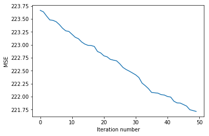

```python
%pylab inline
plot(range(50), stoch_errors_by_iter[:50])
xlabel('Iteration number')
ylabel('MSE')
```

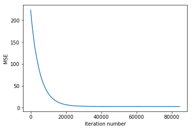

```python
%pylab inline
plot(range(len(stoch_errors_by_iter)), stoch_errors_by_iter)
xlabel('Iteration number')
ylabel('MSE')
```

**Посмотрим на вектор весов, к которому сошелся метод.**

```python
stoch_grad_desc_weights
```

```
array([  1.40190566e+01,   3.91069256e+00,   2.78209808e+00,
        -8.10462217e-03])
```

**Посмотрим на среднеквадратичную ошибку на последней итерации.**

```python
stoch_errors_by_iter[-1]
```

```
2.784412588406703
```

**среднеквадратичная ошибка прогноза значений Sales в виде линейной модели с весами, найденными с помощью градиентного спуска**

```python
answer4 = mserror(y[:,0], linear_prediction(ones_and_X, stoch_grad_desc_weights)) # Ваш код здесь
print(answer4)
```

```
2.78441258841
```

```python
type(y[:,0])
```

```
numpy.ndarray
```

```python
y[:,0]
```

```
array([ 22.1,  10.4,   9.3,  18.5,  12.9,   7.2,  11.8,  13.2,   4.8,
        10.6,   8.6,  17.4,   9.2,   9.7,  19. ,  22.4,  12.5,  24.4,
        11.3,  14.6,  18. ,  12.5,   5.6,  15.5,   9.7,  12. ,  15. ,
        15.9,  18.9,  10.5,  21.4,  11.9,   9.6,  17.4,   9.5,  12.8,
        25.4,  14.7,  10.1,  21.5,  16.6,  17.1,  20.7,  12.9,   8.5,
        14.9,  10.6,  23.2,  14.8,   9.7,  11.4,  10.7,  22.6,  21.2,
        20.2,  23.7,   5.5,  13.2,  23.8,  18.4,   8.1,  24.2,  15.7,
        14. ,  18. ,   9.3,   9.5,  13.4,  18.9,  22.3,  18.3,  12.4,
         8.8,  11. ,  17. ,   8.7,   6.9,  14.2,   5.3,  11. ,  11.8,
        12.3,  11.3,  13.6,  21.7,  15.2,  12. ,  16. ,  12.9,  16.7,
        11.2,   7.3,  19.4,  22.2,  11.5,  16.9,  11.7,  15.5,  25.4,
        17.2,  11.7,  23.8,  14.8,  14.7,  20.7,  19.2,   7.2,   8.7,
         5.3,  19.8,  13.4,  21.8,  14.1,  15.9,  14.6,  12.6,  12.2,
         9.4,  15.9,   6.6,  15.5,   7. ,  11.6,  15.2,  19.7,  10.6,
         6.6,   8.8,  24.7,   9.7,   1.6,  12.7,   5.7,  19.6,  10.8,
        11.6,   9.5,  20.8,   9.6,  20.7,  10.9,  19.2,  20.1,  10.4,
        11.4,  10.3,  13.2,  25.4,  10.9,  10.1,  16.1,  11.6,  16.6,
        19. ,  15.6,   3.2,  15.3,  10.1,   7.3,  12.9,  14.4,  13.3,
        14.9,  18. ,  11.9,  11.9,   8. ,  12.2,  17.1,  15. ,   8.4,
        14.5,   7.6,  11.7,  11.5,  27. ,  20.2,  11.7,  11.8,  12.6,
        10.5,  12.2,   8.7,  26.2,  17.6,  22.6,  10.3,  17.3,  15.9,
         6.7,  10.8,   9.9,   5.9,  19.6,  17.3,   7.6,   9.7,  12.8,
        25.5,  13.4])
```

```python
y[:,0].shape
```

```
(200L,)
```

```python
mark
```

```
'Sales'
```